# TD Tarification Non Vie

Louis Rolland

13 novembre 2018

http://lrapplications.wordpress.com.

Présentation de la base de données :

```r
library(ggplot2)
library(plotrix)
library(DescTools)
library(reshape2)

bd=readRDS("C:/Users/Louis/Documents/EURIA/M2/tarif non vie/base_tarif.rds")

set.seed(31415) ; n=nrow(bd) ; samp=sample(1:n,300000)

bda=bd[samp,] #base d'apprentissage
bdt=bd[-samp,] #base de test

library(data.table)
bd=as.data.table(bd)

head(bd)
```

```
##    Exercice Couverture Nbpieces Nbpers Qualite  Kassu Age Usage
## 1:     2006         C1    1-2-3      1     Loc 12000e  18 PRINC
## 2:     2006         C1    1-2-3      1     Loc 12000e  18 PRINC
## 3:     2006         C1    1-2-3      1     Loc 12000e  19 PRINC
## 4:     2006         C1    1-2-3      1     Loc 12000e  19 SECON
## 5:     2006         C1    1-2-3      1     Loc 12000e  20 PRINC
## 6:     2006         C1    1-2-3      1     Loc 12000e  21 PRINC
##          Local Direct  DMG Zonier_DDE Ante_DDE Zonier_Vol Ante_Vol
## 1: Inter-1-2-3      N DMG2         Z1        0         Z2        0
## 2:      Maison      N DMG2         Z2        0         Z3        0
## 3: Inter-1-2-3      O DMG2         Z2        0         Z2        0
## 4:         Rdc      N DMG1         Z2        0         Z1        0
## 5:    Inter-4+      O DMG1         Z4        0         Z1        0
## 6: Inter-1-2-3      N DMG2         Z3        0         Z3        0
##    Sini_DDE Sini_Vol Cout_DDE Cout_Vol      Expo Dep  Age2
## 1:        0        0        0        0 0.5000000  49 18-25
## 2:        0        0        0        0 0.7232877  71 18-25
## 3:        0        0        0        0 1.0000000  35 18-25
## 4:        0        0        0        0 0.6876712  03 18-25
## 5:        0        0        0        0 0.8333333  83 18-25
## 6:        0        0        0        0 0.5000000  45 18-25
```

```r
colnames(bd)
```

```
##  [1] "Exercice"   "Couverture" "Nbpieces"   "Nbpers"     "Qualite"
##  [6] "Kassu"      "Age"        "Usage"      "Local"      "Direct"
## [11] "DMG"        "Zonier_DDE" "Ante_DDE"   "Zonier_Vol" "Ante_Vol"
## [16] "Sini_DDE"   "Sini_Vol"   "Cout_DDE"   "Cout_Vol"   "Expo"
## [21] "Dep"        "Age2"
```

## Exercice 1

### Question 1

Etudier la base et repérer les variables explicatives tarifaires ainsi que les variables clés de la modélisation

### Question 2

Calculer :

- a Le combre total de contrat souscrits puis le nombre de contrats annuels

```r
nrow(bd)
```

```
## [1] 1112095
```

```r
summary(as.factor(bd$Exercice))
```

```
##   2006   2007   2008   2009   2010   2011   2012   2013
## 114529 129332 136916 140256 143720 146899 149381 151062
```

- b L’exposition global du portefeuille

```r
sum(bd$Expo)
```

```
## [1] 1172479
```

- c Le nombre et le coût total des sinistres

```r
c(sum(bd$Sini_DDE),sum(bd$Cout_DDE))
```

```
## [1]    20658 27197254
```

- d La fréquence gloable de sinistralité

```r
sum(bd$Sini_DDE)/sum(bd$Expo)
```

```
## [1] 0.01761908
```

- e Le coût moyen d’un sinistres

```r
sum(bd$Cout_DDE)/sum(bd$Sini_DDE)
```

```
## [1] 1316.548
```

### QUestion 3

Mêmes questions, mais par année

```r
bd[,list(Expo=sum(Expo), nb=sum(Sini_DDE),cout=sum(Cout_DDE),freq=sum(Sini_DDE)/sum(Expo),CM=sum(Cout_DDE)/sum(Sini_DDE)),by=Exercice]
```

```
##    Exercice     Expo   nb    cout       freq       CM
## 1:     2006 116354.1 2089 2809863 0.01795382 1345.076
## 2:     2007 135147.8 2392 3063857 0.01769914 1280.877
## 3:     2008 143153.3 2535 3139635 0.01770829 1238.515
## 4:     2009 148040.1 2642 3654678 0.01784652 1383.300
## 5:     2010 152351.1 2596 3511526 0.01703958 1352.668
## 6:     2011 156833.2 2829 4018922 0.01803827 1420.616
## 7:     2012 159019.7 2783 3502744 0.01750097 1258.622
## 8:     2013 161579.4 2792 3496029 0.01727943 1252.159
```

### Question 4

Sinistralité extrême : Étudier les valeurs extrêmes en DDE

```r
mean(bd$Cout_DDE[bd$Cout_DDE>0])
```

```
## [1] 1389.813
```

```r
max(bd$Cout_DDE)
```

```
## [1] 90049.29
```

```r
sum(bd$Sini_DDE[bd$Cout_DDE>0])
```

```
## [1] 20658
```

```r
sum(bd$Sini_DDE[bd$Cout_DDE>5e4])
```

```
## [1] 7
```

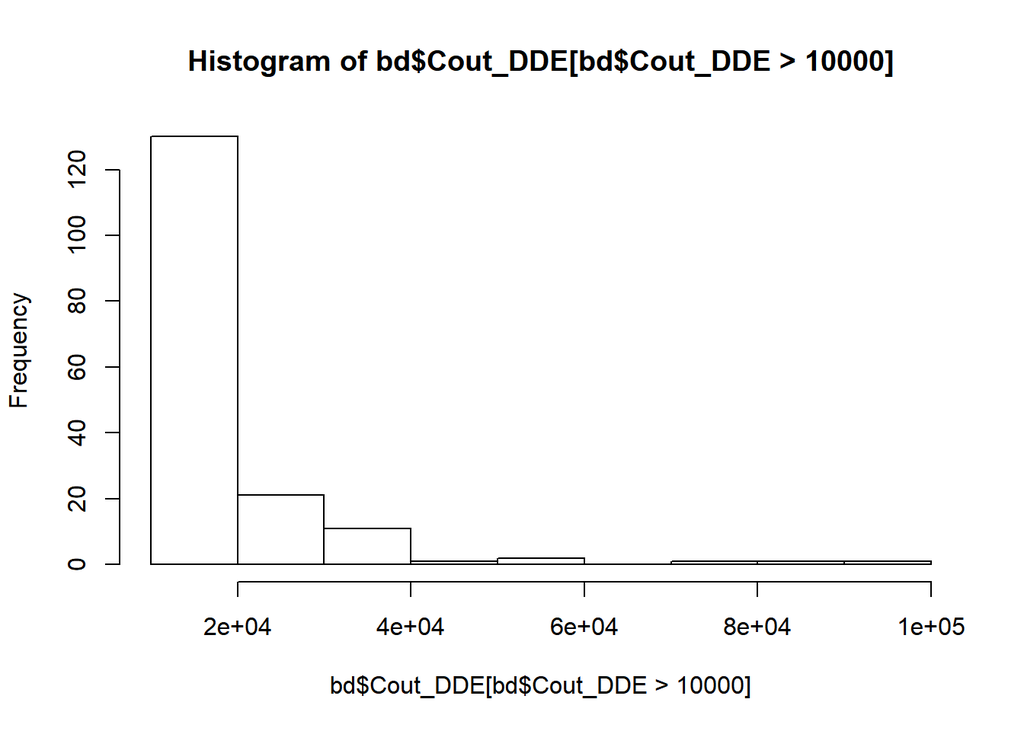

```r
hist(bd$Cout_DDE[bd$Cout_DDE>1e4])
```

## Exercice 2

Étude de la sinistralité globale.

### Question 1

Stabilité temporelle de la variable “Couverture” au sein de portefeuille.

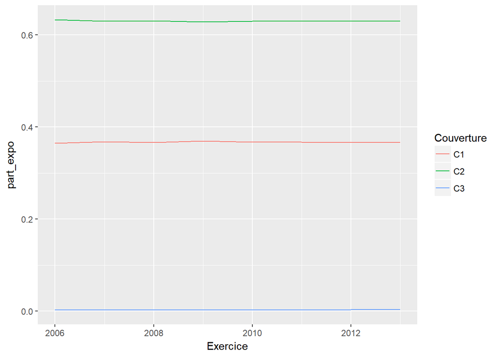

```r
tab=bd[,list(Expo=sum(Expo)), by=list(Exercice,Couverture)]

tab$part_expo=sapply(1:length(tab$Expo),function(i) tab$Expo[i]/sum(tab$Expo[(tab$Exercice==tab$Exercice[i])]))

ggplot(tab,aes(x=Exercice,y=part_expo,group=Couverture,col=Couverture))+geom_line()
```

### Question 2

Analyse univariée : Etudier les fréquences et coûts moyens pour chaque modalité de la variable“Couverture”.

```r
bd[,sum(Sini_DDE)/sum(Expo),by=Couverture][order(Couverture)]
```

```
##    Couverture         V1
## 1:         C1 0.01601108
## 2:         C2 0.01848887
## 3:         C3 0.03108952
```

```r
bd[,sum(Cout_DDE)/sum(Sini_DDE),by=Couverture][order(Couverture)]
```

```
##    Couverture       V1
## 1:         C1 1316.206
## 2:         C2 1312.375
## 3:         C3 1832.498
```

```r
tab=bd[,list(Expo=sum(Expo)/sum(bd$Expo),
             Freq=sum(Sini_DDE)/sum(Expo),
             CM=sum(Cout_DDE)/sum(Sini_DDE),
             CG=sum(Cout_DDE)/sum(Expo) ),
       by=Couverture][order(Couverture)]

tab
```

```
##    Couverture        Expo       Freq       CM       CG
## 1:         C1 0.367076611 0.01601108 1316.206 21.07388
## 2:         C2 0.629768538 0.01848887 1312.375 24.26432
## 3:         C3 0.003154851 0.03108952 1832.498 56.97147
```

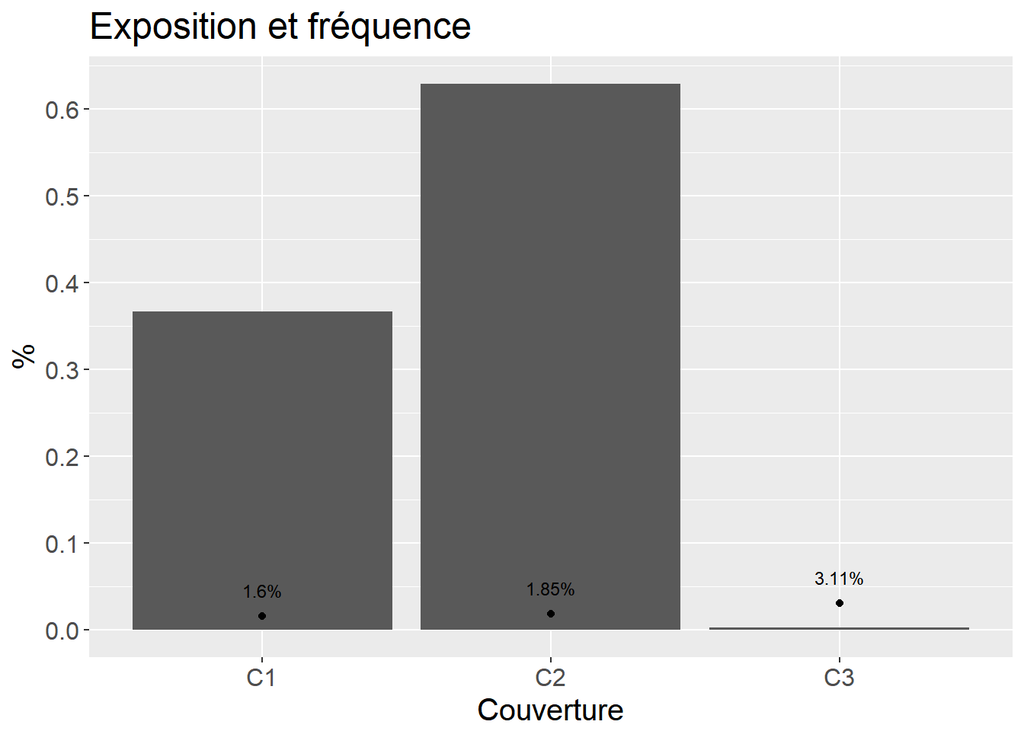

```r
ggplot(tab)+
  geom_bar(aes(x=Couverture,weight=Expo))+
  geom_point(aes(x=Couverture,y=Freq,label=Freq))+ geom_text(aes(x=Couverture,y=0.03+Freq,label=paste(round(100*Freq,2),"%",sep="")),size=3)+
  theme(text = element_text(size=15))+
  ggtitle("Exposition et fréquence")+
  scale_y_continuous(name="%", breaks=seq(0,1,by=0.1))
```

### Question 3

Etude de la stabilité annuelle des fréquences et coûts moyens.

```r
bd[,sum(Sini_DDE)/sum(Expo),by=list(Couverture,Exercice)][order(Couverture,Exercice)]
```

```
##     Couverture Exercice          V1
##  1:         C1     2006 0.016014753
##  2:         C1     2007 0.015599969
##  3:         C1     2008 0.016832604
##  4:         C1     2009 0.017233148
##  5:         C1     2010 0.015368605
##  6:         C1     2011 0.016137162
##  7:         C1     2012 0.015198204
##  8:         C1     2013 0.015782046
##  9:         C2     2006 0.018980132
## 10:         C2     2007 0.018976401
## 11:         C2     2008 0.018188906
## 12:         C2     2009 0.018188300
## 13:         C2     2010 0.017934697
## 14:         C2     2011 0.018936460
## 15:         C2     2012 0.018752138
## 16:         C2     2013 0.018095129
## 17:         C3     2006 0.036892145
## 18:         C3     2007 0.007224544
## 19:         C3     2008 0.023123429
## 20:         C3     2009 0.021687291
## 21:         C3     2010 0.032081067
## 22:         C3     2011 0.064301878
## 23:         C3     2012 0.034518359
## 24:         C3     2013 0.028660820
##     Couverture Exercice          V1
```

```r
bd[,sum(Cout_DDE)/sum(Sini_DDE),by=list(Couverture,Exercice)][order(Couverture,Exercice)]
```

```
##     Couverture Exercice        V1
##  1:         C1     2006 1375.4835
##  2:         C1     2007 1271.2874
##  3:         C1     2008 1273.8595
##  4:         C1     2009 1386.6308
##  5:         C1     2010 1323.4758
##  6:         C1     2011 1391.9038
##  7:         C1     2012 1288.3980
##  8:         C1     2013 1224.0081
##  9:         C2     2006 1312.1202
## 10:         C2     2007 1282.9531
## 11:         C2     2008 1222.3859
## 12:         C2     2009 1383.0415
## 13:         C2     2010 1364.1586
## 14:         C2     2011 1434.6002
## 15:         C2     2012 1235.0743
## 16:         C2     2013 1260.0118
## 17:         C3     2006 3298.2866
## 18:         C3     2007 2640.9082
## 19:         C3     2008  807.4532
## 20:         C3     2009 1113.2023
## 21:         C3     2010 1683.9252
## 22:         C3     2011 1439.6131
## 23:         C3     2012 2251.0706
## 24:         C3     2013 2047.4616
##     Couverture Exercice        V1
```

### Question 4

Analyse bivariée : Etudier fréquences et coûts moyen pour chaque croisement de modalités des variables “Nbpieces” et “Nbpers”.

```r
bd[,sum(Sini_DDE)/sum(Expo),by=list(Nbpieces,Nbpers)][order(Nbpieces,Nbpers)]
```

```
##     Nbpieces Nbpers         V1
##  1:    1-2-3      1 0.01490692
##  2:    1-2-3      2 0.01673283
##  3:    1-2-3      3 0.01884831
##  4:    1-2-3      4 0.01906757
##  5:    1-2-3    >=5 0.01931465
##  6:      4-5      1 0.01590764
##  7:      4-5      2 0.01600086
##  8:      4-5      3 0.01700333
##  9:      4-5      4 0.01899376
## 10:      4-5    >=5 0.01893607
## 11:      6-8      1 0.02033863
## 12:      6-8      2 0.01932005
## 13:      6-8      3 0.02392948
## 14:      6-8      4 0.02189039
## 15:      6-8    >=5 0.02458097
## 16:      >=9      1 0.03686130
## 17:      >=9      2 0.02976643
## 18:      >=9      3 0.04268657
## 19:      >=9      4 0.03993946
## 20:      >=9    >=5 0.03123102
```

```r
bd[,sum(Sini_DDE)/sum(Expo),by=list(Qualite,Nbpers)]
```

```
##     Qualite Nbpers         V1
##  1:     Loc      1 0.01304192
##  2:    Prop      1 0.01900569
##  3:     Loc      2 0.01501233
##  4:    Prop      2 0.01836494
##  5:     Loc      3 0.01602014
##  6:    Prop      3 0.02171961
##  7:     Loc      4 0.01785702
##  8:    Prop      4 0.02163768
##  9:     Loc    >=5 0.01801605
## 10:    Prop    >=5 0.02332897
```

```r
bd[,sum(Sini_DDE)/sum(Expo),by=list(Qualite,Local)]
```

```
##     Qualite       Local         V1
##  1:     Loc Inter-1-2-3 0.01741716
##  2:     Loc      Maison 0.01172473
##  3:     Loc         Rdc 0.01601240
##  4:     Loc    Inter-4+ 0.01823566
##  5:     Loc     Dernier 0.01363076
##  6:    Prop     Dernier 0.02832959
##  7:    Prop      Maison 0.01633105
##  8:    Prop    Inter-4+ 0.03043129
##  9:    Prop Inter-1-2-3 0.03030375
## 10:    Prop         Rdc 0.02827349
```

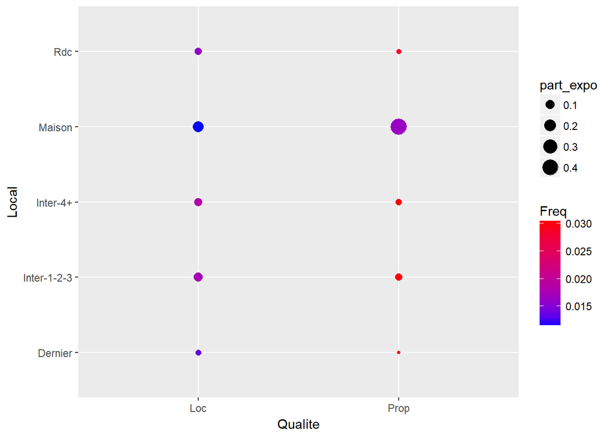

```r
tab=bd[,list(Expo=sum(Expo),part_expo=sum(Expo)/sum(bd$Expo),Freq=sum(Sini_DDE)/sum(Expo)),
       by=list(Qualite,Local)]

ggplot(tab)+geom_point(aes(x=Qualite,y=Local,size=part_expo,col=Freq))+
  scale_colour_gradient(high = "red",low="blue")
```

### Question 5

Etude de la sinistralité (fréquences et coûts moyens) par âge.

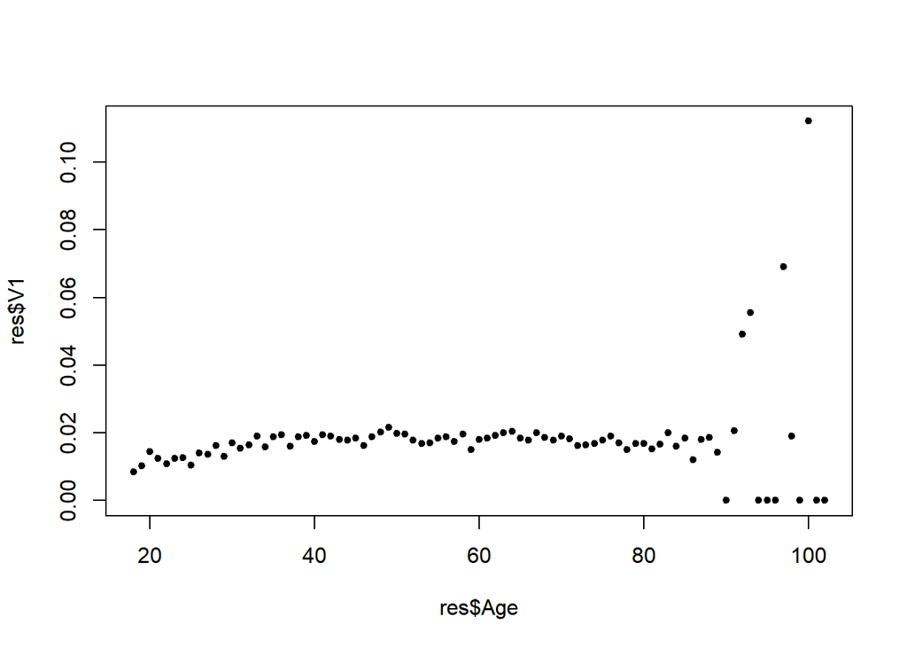

```r
res=bd[,sum(Sini_DDE)/sum(Expo),by=Age][order(Age)] ; plot(res$Age,res$V1,pch=20)
```

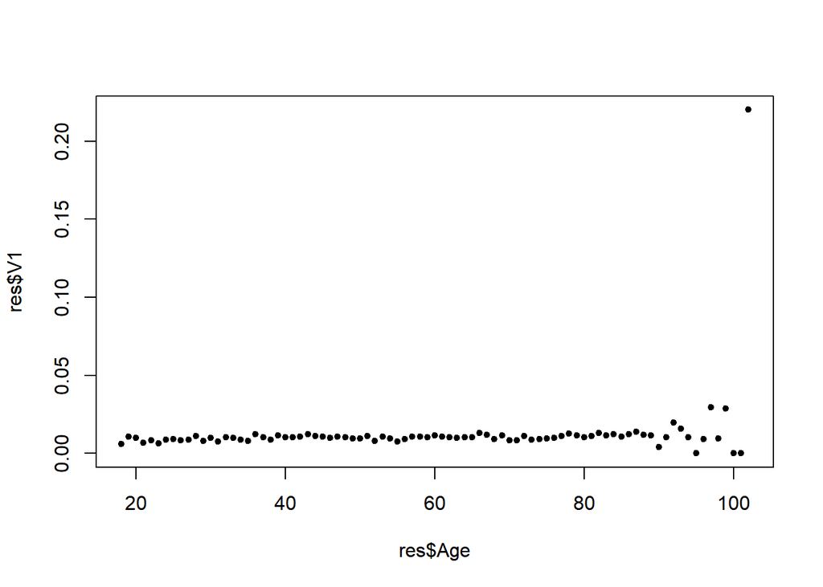

```r
res=bd[,sum(Sini_Vol)/sum(Expo),by=Age][order(Age)] ; plot(res$Age,res$V1,pch=20)
```

```r
bd$Age2=rep("#",length(bd$Age))
bd$Age2[bd$Age<=25]="a. <=25"
bd$Age2[bd$Age>=26 & bd$Age <=34]="b. 26-34"
bd$Age2[bd$Age>=35 & bd$Age <=49]="c. 35-49"
bd$Age2[bd$Age>=50 & bd$Age <=64]="d. 50-64"
bd$Age2[bd$Age>=65]="e. >=65"

bda=bd[samp,] ; bdt=bd[-samp,]
```

### Question 6

Même question pour le département

```r
bd[,sum(Sini_DDE)/sum(Expo),by=Dep][order(Dep)]
```

```
##     Dep          V1
##  1:  00 0.325799768
##  2:  01 0.014508495
##  3:  02 0.011694056
##  4:  03 0.009731631
##  5:  04 0.020832853
##  6:  05 0.012105355
##  7:  06 0.038815054
##  8:  07 0.022543426
##  9:  08 0.007945216
## 10:  09 0.014330058
## 11:  10 0.011829963
## 12:  11 0.019547763
## 13:  12 0.011583328
## 14:  13 0.025300191
```

[output cut: 83 more lines]

### Question 7

Calculer la corrélation entre variables tarifaires potentielles.

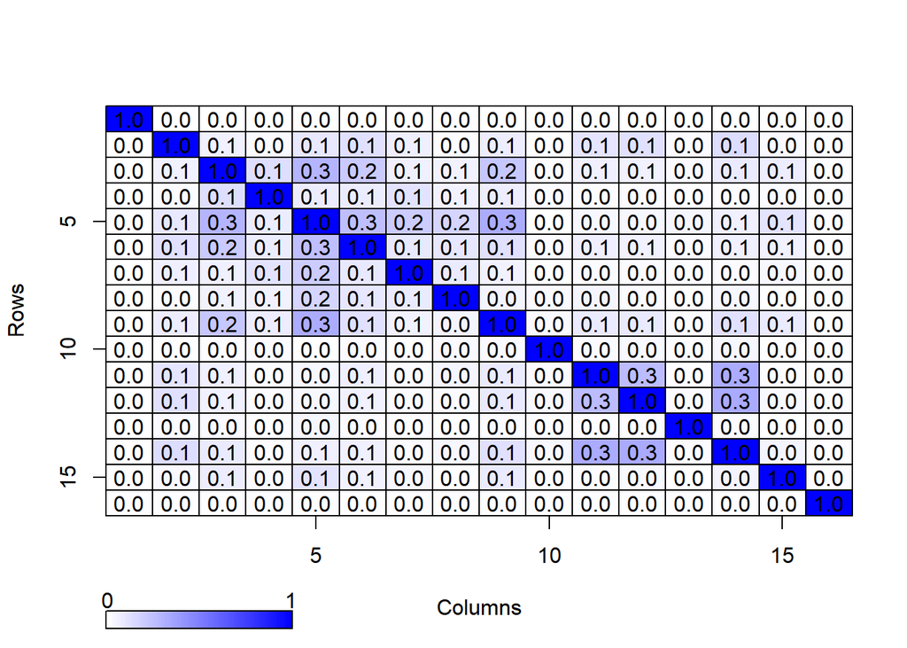

```r
var_freq=c("Exercice","Couverture","Nbpieces","Nbpers","Qualite","Kassu","Age2",
           "Usage","Local","Direct","DMG","Zonier_DDE","Ante_DDE",
           "Zonier_Vol","Ante_Vol","Dep")

bd=as.matrix(bd)
res=matrix(NA,nrow=length(var_freq),ncol=length(var_freq))
for (i in 1:length(var_freq)) {
  for (j in 1:length(var_freq)) {
    res[i,j]=CramerV(bd[,(var_freq[i])],bd[,(var_freq[j])])
  }}
colnames(res)=var_freq
rownames(res)=var_freq

color2D.matplot(res, extremes = c("white", "blue"), vcol = "black",nslices = 60,
                show.legend=TRUE,axes=TRUE,show.values=TRUE,xlab="Columns",ylab="Rows")
```

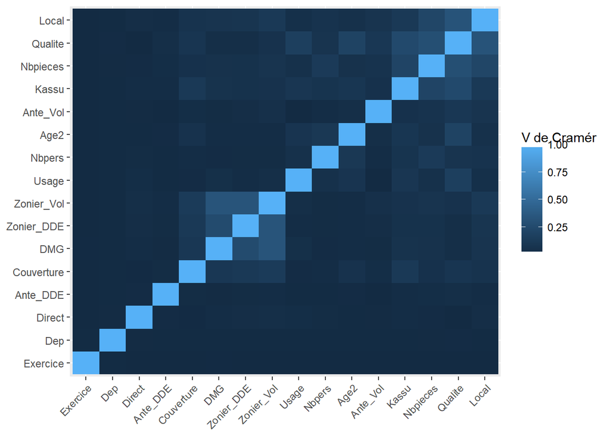

```r
neworder=hclust(dist(res))$order
res2=res[neworder,neworder]

qplot(x=Var1, y=Var2, data=melt(res2), fill=value, geom="tile") +
  theme(axis.text.x = element_text(angle = 45, vjust = 1, hjust=1)) +
  xlab(NULL)+ylab(NULL)+labs(fill="V de Cramér")
```

## Exercice 3

## Exercice 4

## Exercice 5